# SDS 164 Project: Stage 3

Rough Draft

## Introduction

Across the globe, we often measure a country’s success by its wealth or its health, but these numbers rarely tell the full story of what life is actually like for the people living there.The data tells a compelling story about the deep-seated relationship between gender equality and a nation’s overall prosperity and well-being, whether a country’s ability to provide high-quality education, long life expectancy, and economic opportunity is tied to how fairly it treats its women. Understanding this connection challenges the idea that economic growth can happen in a vacuum; it suggests that for a country to truly flourish, it must first ensure that half of its population isn’t being left behind.[^1]

This analysis draws on data compiled by the United Nations Development Programme (UNDP) for the year 2023, capturing a comprehensive snapshot of 191 countries and territories.[^2] Each observation represents a specific nation, from small island states to the world’s largest economies. Two primary indices anchor the analysis: the Human Development Index (HDI), which measures average achievements in health, knowledge, and standard of living, and the Gender Inequality Index (GII), which tracks disadvantages specifically faced by women in health, empowerment, and the labor market. These scores are built from real-world metrics, years children spend in school, the percentage of seats women hold in national parliaments, and gross national income per person, allowing us to see how gender parity drives, or is held back by, a nation’s development.

## Figures

### The Core Relationship: Gender Inequality and Human Development

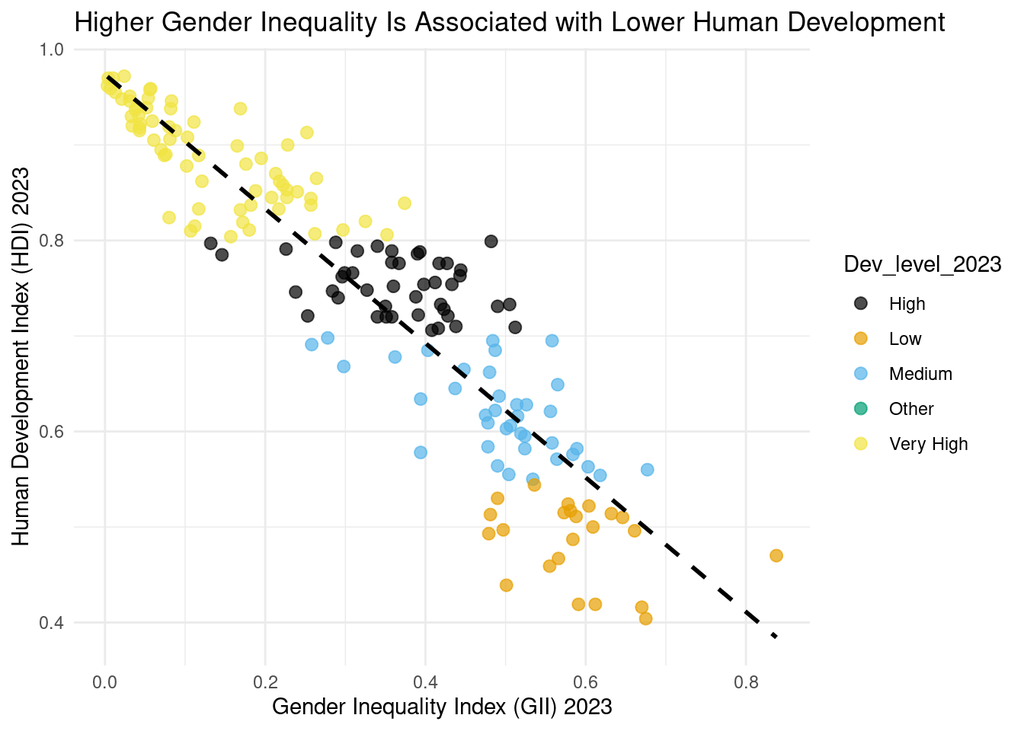

Figure 1. Countries with higher gender inequality consistently show lower human development. This scatterplot displays HDI against GII for countries with complete data in the 2023 UNDP dataset. Points are color-coded by development category (Very High, High, Medium, Low), and a smoothed trend line summarizes the overall negative relationship.

```r
HDI_GII_2023 |>
  ggplot(aes(x = GII_value_2023, y = HDI_value, color = Dev_level_2023)) +
  geom_point(alpha = 0.7, size = 2.5, na.rm = TRUE) +
  geom_smooth(method = "lm", color = "black", se = FALSE, linetype = "dashed", na.rm = TRUE) +
  labs(
    x = "Gender Inequality Index (GII) 2023",
    y = "Human Development Index (HDI) 2023",
    title = "Higher Gender Inequality Is Associated with Lower Human Development"
  ) +
  scale_color_colorblind() +
  theme_minimal()
```

### Gender Inequality Across Development Levels

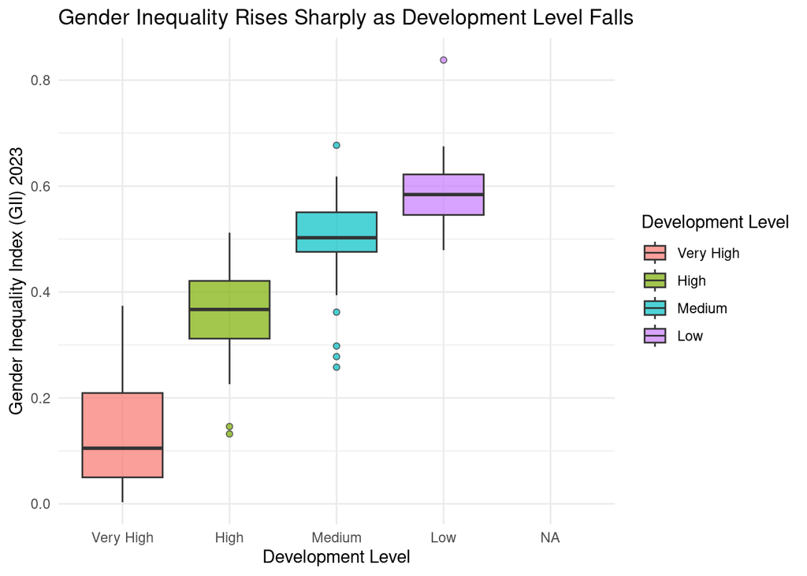

```r
HDI_GII_2023 |>
  mutate(Dev_level_2023 = factor(Dev_level_2023,
                            levels = c("Very High", "High", "Medium", "Low"))) |>
  ggplot(aes(x = Dev_level_2023, y = GII_value_2023, fill = Dev_level_2023, nar.rm = TRUE)) +
  geom_boxplot(alpha = 0.7, outlier.shape = 21, na.rm = TRUE) +
  labs(
    x = "Development Level",
    y = "Gender Inequality Index (GII) 2023",
    title = "Gender Inequality Rises Sharply as Development Level Falls",
    fill = "Development Level"
  ) +
  scale_color_colorblind() +
  theme_minimal()
```

### Women in Parliament and Human Development

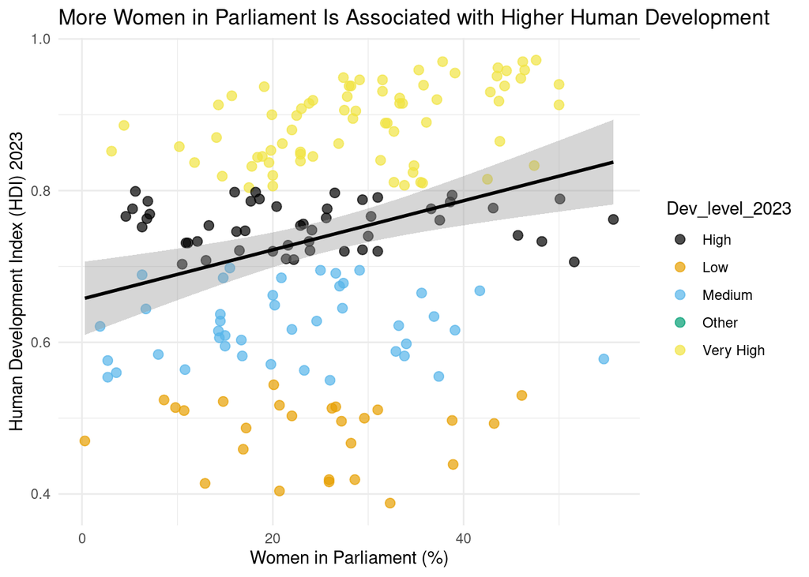

Figure 3. Countries where women hold more parliamentary seats tend to have higher human development, though the relationship is weaker than the overall GII-HDI association. This scatterplot shows the percentage of parliamentary seats held by women against HDI for countries with available data in the 2023 UNDP dataset. A linear regression line is included. The percentage of parliamentary seats held by women serves as a concrete measure of women’s political empowerment, one component of the GII.

```r
HDI_GII_2023 |>
  filter(!is.na(parl_women)) |>
  ggplot(aes(x = parl_women, y = HDI_value, color = Dev_level_2023)) +
  geom_point(alpha = 0.7, size = 2.5, na.rm = TRUE) +
  geom_smooth(method = "lm", color = "black", se = TRUE, na.rm = TRUE) +
  labs(
    x = "Women in Parliament (%)",
    y = "Human Development Index (HDI) 2023",
    title = "More Women in Parliament Is Associated with Higher Human Development"
  ) +
  scale_color_colorblind() +
  theme_minimal()
```

## Conclusion

These findings align with a growing body of research arguing that gender equity is not merely a social justice issue, but an economic and developmental imperative. When women are excluded from labor markets, parliaments, and schools, entire societies pay the price in the form of lower productivity, worse health outcomes, and reduced innovation. Conversely, the countries that have achieved the highest levels of human development, the Scandinavian nations, for example, are also those that have made the most progress toward gender parity.

Of course, correlation does not imply causation, and the relationship between GII and HDI is almost certainly bidirectional. Wealthier, more developed countries may have more resources to invest in gender equity programs, creating a virtuous cycle. Future analyses might benefit from longitudinal data, tracking whether improvements in GII over time predict subsequent gains in HDI, to better establish the direction of this relationship. Nonetheless, the 2023 UNDP data makes one thing clear: no country has achieved very high human development while leaving its women behind.

[^1]: United Nations Development Programme. “Human Development Report 2023/2024: Breaking the Gridlock.” UNDP, 2024. https://hdr.undp.org/
[^2]: United Nations Development Programme. “Gender Inequality Index (GII).” Human Development Reports, 2023. https://hdr.undp.org/data-center/thematic-composite-indices/gender-inequality-index